# milestone_5

Amy Tan

10/18/2019

## About Page:

In this project, I used two datasets to figure out if there are any interesting correlations between economic variables and educational variables at the Census tract-level nationwide. How do students’ broader social environments impact their academic achievement? I attempt to answer this question by getting the tract_covariates dataset from the Opportunity Insights website (https://opportunityinsights.org/data/) and the stanforddata dataset from the Stanford Education Data Archive (https://exhibits.stanford.edu/data/catalog/db586ns4974). The tract_covariates dataset describes economic and social factors of each Census tract, such as rates of intergenerational mobility and umemployment rates. The stanforddata dataset describes various academic variables for 3rd-8th graders across the nation by tract as well. It contains variables for academic achievement and student demographics. I merged these two datasets together by their FIPS code. I also descriptively analyzed each dataset to find trends within the datasets themselves, such as the correlation between race and income in the tract_covariates dataset. The graph below is one of these descriptive analyses, using the Opportunity Atlas dataset.

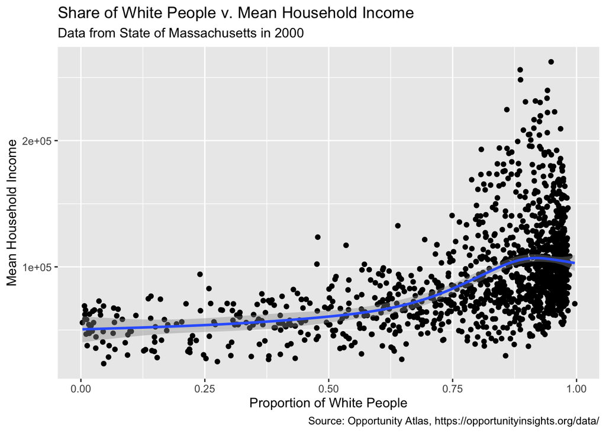